### Link Referred for Fast median

https://en.wikipedia.org/wiki/Quickselect

### Configurations

Statistics:

### Implementation

We have calculated different statistics in the following way:-

#### Mean

The Mapper code reads the input files as pairs and emits key value pairs. We are cleaning each file and performing sanity check in the Mapper. The Key is carrier code and month separated by tab.

The reducer code then sums all the average ticket prices for each carrier code and take the average using the total count of that particular key.

#### Median

The Mapper code reads the input files as pairs and emits key value pairs. We are cleaning each file and performing sanity check in the Mapper. The Key is carrier code and month separated by tab.

The reducer code then sorts all the average ticket prices of a particular key and finds the middle value as the median price.

#### Fast Median

The Mapper code reads the input files as pairs and emits key value pairs. We are cleaning each file and performing sanity check in the Mapper. The Key is carrier code and month separated by tab.

The reducer code then finds the median price by using QuickSelect algorithm which has a running time of O(n).

Assumptions: We have only considered Average Ticket Prices for 2015 flights.

### Benchmarking Harness

We calculate execution time of each configuration in sequence and dump the time in a csv file. We achieve this using the Linux Makefile script where each configuration is run in sequence and time is fetched. We are using R to read the csv files and plot a graph.

### Graph Plot

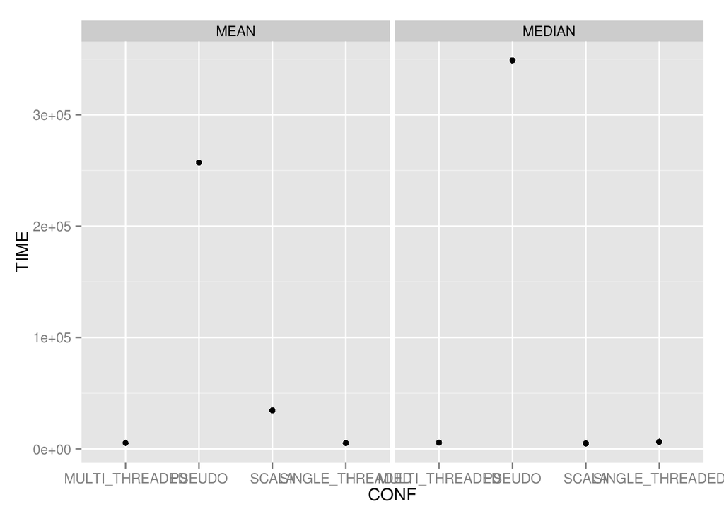

```r
#Plot configuration vs timing and for each statistic calculated
p <- ggplot(table, aes(CONF, TIME)) + geom_point()
p + facet_grid(. ~ MODE)
```

### Sample Output:

This is the output of MeanComparison with a sample input of one file.

1 AA 43971 530.1824 1 AS 13213 230.10681 1 B6 21579 523.64746 1 DL 64082 598.80695 1 EV 49589 305.67844 1 F9 6824 131.74747 1 HA 6434 302.6006 1 MQ 29635 288.26422 1 NK 8730 487.5079 1 OO 47737 307.34674 1 UA 38324 969.1005 1 US 33424 600.1598 1 VX 4726 652.921 1 WN 99553 159.35498